# Heart Failure Prediction

This is the third data product for my university course.  
It's aim is to predict heart failure using a classification model.  
The dataset can be found here:  
https://www.kaggle.com/andrewmvd/heart-failure-clinical-data  
Created by: Dobosi Peter MW79ON

## The plan:

1. Load and explore the data.
2. Clean and transform
3. Choose and fit a model
4. Evaluate and improve
5. Use the best performing model to create the final prediction.

So let's load the data.

```python
import pandas as pd
import matplotlib.pyplot as plt
import seaborn as sns; sns.set()
```

```python
data = pd.read_csv("./heart_data.csv")
data.head()
data.tail()
```

|  | age | anaemia | creatinine_phosphokinase | diabetes | ejection_fraction | high_blood_pressure | platelets | serum_creatinine | serum_sodium | sex | smoking | time | DEATH_EVENT |
| --- | --- | --- | --- | --- | --- | --- | --- | --- | --- | --- | --- | --- | --- |
| 294 | 62.0 | 0 | 61 | 1 | 38 | 1 | 155000.0 | 1.1 | 143 | 1 | 1 | 270 | 0 |
| 295 | 55.0 | 0 | 1820 | 0 | 38 | 0 | 270000.0 | 1.2 | 139 | 0 | 0 | 271 | 0 |
| 296 | 45.0 | 0 | 2060 | 1 | 60 | 0 | 742000.0 | 0.8 | 138 | 0 | 0 | 278 | 0 |
| 297 | 45.0 | 0 | 2413 | 0 | 38 | 0 | 140000.0 | 1.4 | 140 | 1 | 1 | 280 | 0 |
| 298 | 50.0 | 0 | 196 | 0 | 45 | 0 | 395000.0 | 1.6 | 136 | 1 | 1 | 285 | 0 |

We have a little bit les than 300 observations. Let's check wheter we have any NAs.

```python
data.isnull().sum()
```

```
age                         0
anaemia                     0
creatinine_phosphokinase    0
diabetes                    0
ejection_fraction           0
high_blood_pressure         0
platelets                   0
serum_creatinine            0
serum_sodium                0
sex                         0
smoking                     0
time                        0
DEATH_EVENT                 0
dtype: int64
```

After loading the data, and finding out that we have no nulls, let's explore the data for a bit.

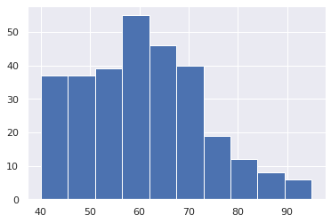

```python
plt.hist(data.age)
```

We can see, that the participants of the study are aged between 40 and 95.

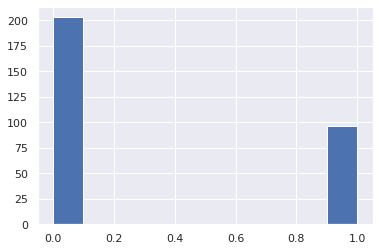

```python
plt.hist(data.DEATH_EVENT)
```

We can also see, that we half as much deaths as non-deaths in the data.

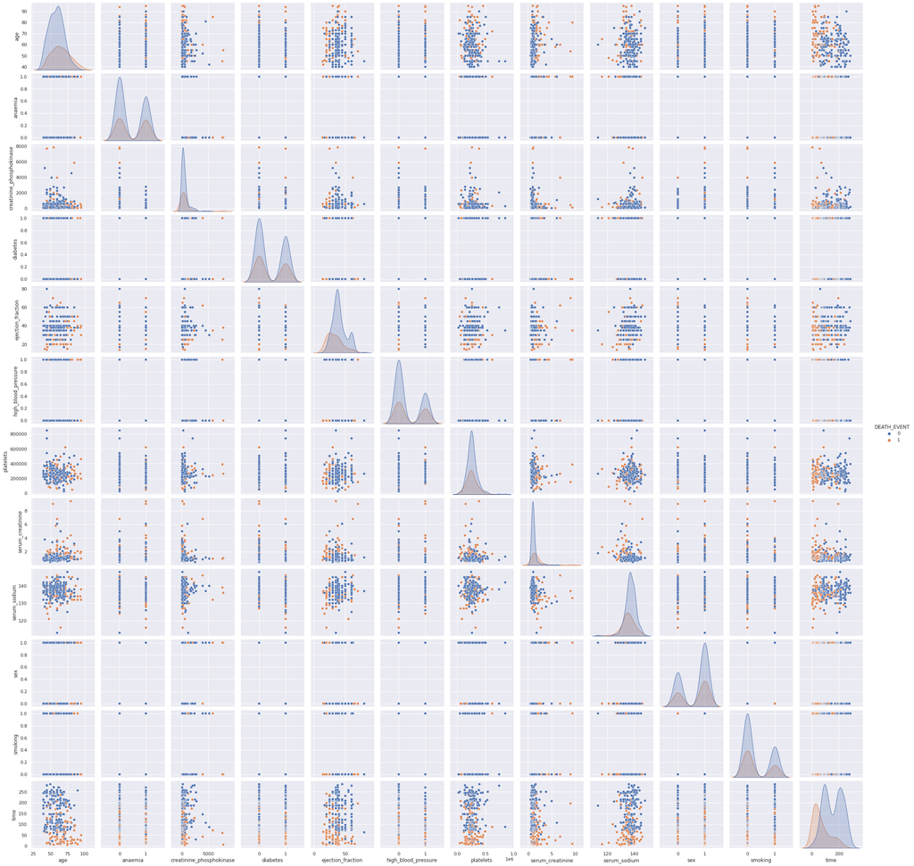

```python
sns.pairplot(data, hue='DEATH_EVENT')
```

We can't really see any clear correlation, between most of these parameters, but a couple of them are better than the rest.

Let's check out the correlations.

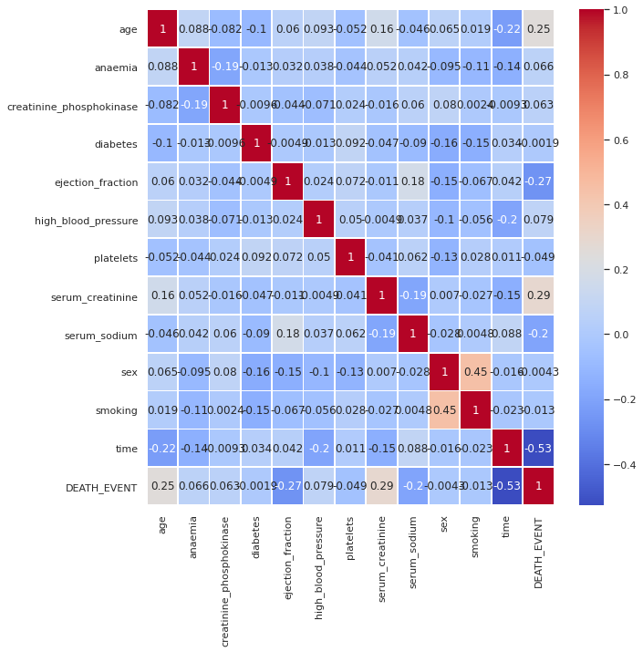

```python
fig, ax = plt.subplots(figsize=(10,10))
sns.heatmap(data.corr(), annot=True, linewidths=.7, ax=ax, cmap="coolwarm")
```

```python
data.corr()["DEATH_EVENT"].sort_values()
```

```
time                       -0.526964
ejection_fraction          -0.268603
serum_sodium               -0.195204
platelets                  -0.049139
smoking                    -0.012623
sex                        -0.004316
diabetes                   -0.001943
creatinine_phosphokinase    0.062728
anaemia                     0.066270
high_blood_pressure         0.079351
age                         0.253729
serum_creatinine            0.294278
DEATH_EVENT                 1.000000
Name: DEATH_EVENT, dtype: float64
```

We can see, that the four most relevant parameters are:

1. time
2. serum_creatinine
3. ejection_fraction
4. age

Let's use these. But first, we have to check wheter there are any outliers in them.

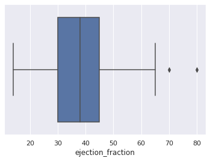

```python
sns.boxplot(x = data.ejection_fraction)
```

We have two outliers, let's remove them.

```python
data = data[data['ejection_fraction']<65]
```

Let's check time for outliers:

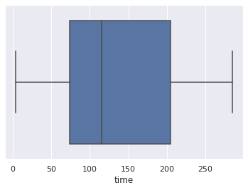

```python
sns.boxplot(x = data.time)
```

Luckily, we don't have any here.

Let's also check the serum_creatinine parameter:

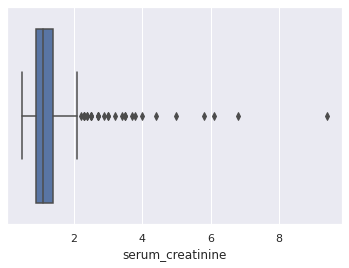

```python
sns.boxplot(x = data.serum_creatinine)
```

Finally let's take a look at the age parameter.

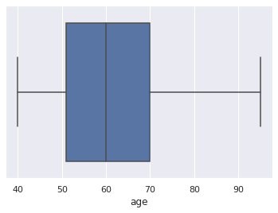

```python
sns.boxplot(x = data.age)
```

This looks fine as well.

After exploring the data for a bit, let's build some models.  
But before we can do that, we have to shape our dataframe into the correct form, so let's do that now:

First things first, we have to create the Series containing the ground truth:

```python
y = data.DEATH_EVENT
y
```

```
0      1
1      1
2      1
3      1
4      1
      ..
294    0
295    0
296    0
297    0
298    0
Name: DEATH_EVENT, Length: 296, dtype: int64
```

After that we have to create the parameter matrix:

```python
X = data[["ejection_fraction", "time", "serum_creatinine", "age"]]
X
```

|  | ejection_fraction | time | serum_creatinine | age |
| --- | --- | --- | --- | --- |
| 0 | 20 | 4 | 1.9 | 75.0 |
| 1 | 38 | 6 | 1.1 | 55.0 |
| 2 | 20 | 7 | 1.3 | 65.0 |
| 3 | 20 | 7 | 1.9 | 50.0 |
| 4 | 20 | 8 | 2.7 | 65.0 |
| ... | ... | ... | ... | ... |
| 294 | 38 | 270 | 1.1 | 62.0 |
| 295 | 38 | 271 | 1.2 | 55.0 |
| 296 | 60 | 278 | 0.8 | 45.0 |
| 297 | 38 | 280 | 1.4 | 45.0 |
| 298 | 45 | 285 | 1.6 | 50.0 |

296 rows × 4 columns

Now everything is in the correct shape.  
But before we can start building models, we have to split the available data, into train and test sets:

```python
from sklearn.model_selection import train_test_split
Xtrain, Xtest, ytrain, ytest = train_test_split(X, y)
```

After preparing the data, it is time to finally build some models.  
Let's start with a simple Naive Bayes:

```python
from sklearn.naive_bayes import GaussianNB
NBmodel = GaussianNB()
NBmodel.fit(Xtrain, ytrain);
```

Let's check out the accuracy of this model:

```python
yNBmodel = NBmodel.predict(Xtest)
from sklearn.metrics import accuracy_score
accuracy_score(ytest, yNBmodel)
```

```
0.7837837837837838
```

A bit shy of 80%. Not bad for a simple model, but let's try to improve it.  
Perhaps an SVM model could achieve a better result:

```python
from sklearn.svm import SVC
from sklearn.model_selection import GridSearchCV

param_grid = {"C": [1E-1, 1E0, 1E1, 1E2, 1E3],
             "kernel": ['rbf'],
             "gamma": ['scale','auto']}

grid = GridSearchCV(SVC(), param_grid)
grid.fit(Xtrain, ytrain)
```

```
GridSearchCV(estimator=SVC(),
             param_grid={'C': [0.1, 1.0, 10.0, 100.0, 1000.0],
                         'gamma': ['scale', 'auto'], 'kernel': ['rbf']})
```

```python
grid.best_params_
```

```
{'C': 10.0, 'gamma': 'scale', 'kernel': 'rbf'}
```

```python
SVCmodel = grid.best_estimator_
```

Let's check out the accuracy:

```python
ySVCmodel = SVCmodel.predict(Xtest)
from sklearn.metrics import accuracy_score
accuracy_score(ytest, ySVCmodel)
```

```
0.7972972972972973
```

Sadly we couldn't improve our model this way.  
After a new run, it's a tiny bit better. Probaly because of the train-test split.  
Let's try a KNN model aswell:

```python
from sklearn.neighbors import KNeighborsClassifier

param_grid = {"n_neighbors": [1, 2, 3, 4, 5, 6, 7, 8, 9, 10],
              "weights": ["uniform", "distance"]}

grid = GridSearchCV(KNeighborsClassifier(), param_grid)
grid.fit(Xtrain, ytrain)
```

```
GridSearchCV(estimator=KNeighborsClassifier(),
             param_grid={'n_neighbors': [1, 2, 3, 4, 5, 6, 7, 8, 9, 10],
                         'weights': ['uniform', 'distance']})
```

```python
grid.best_params_
```

```
{'n_neighbors': 6, 'weights': 'uniform'}
```

```python
KNNmodel = grid.best_estimator_
yKNNmodel = KNNmodel.predict(Xtest)
accuracy_score(ytest, yKNNmodel)
```

```
0.7837837837837838
```

Let's check out the confusion matrixes for our models:

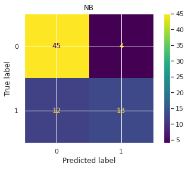

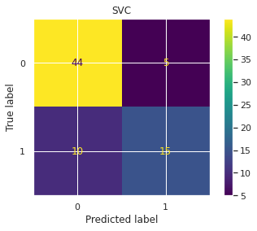

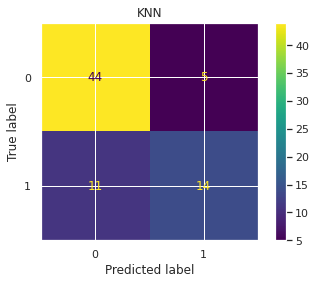

```python
from sklearn.metrics import plot_confusion_matrix

plot_confusion_matrix(NBmodel, Xtest, ytest)
plt.title("NB")
plot_confusion_matrix(SVCmodel, Xtest, ytest)
plt.title("SVC")
plot_confusion_matrix(KNNmodel, Xtest, ytest)
plt.title("KNN")
```

Based simply on accuracy, the SVC model performed best.  
In this task finding the positives are the most important factor, even at the cost of false postives.  
Taking a look at the confusion matrixes, we can see that the SVC is the best model for that aswell.  
In conclusion, we should use the SVC model for prediciting future cases.